# Bank Customer Churn Analysis & Feature Importance

**Gibran Ariq Natakusuma**

**DSML-41**

## 1. Import Library & Data Loading

Mengimport seluruh library yang dibutuhkan dalam satu cell untuk konsistensi dan kemudahan maintenance.

```python
import pandas as pd
import numpy as np
import matplotlib.pyplot as plt
import seaborn as sns
from scipy import stats
import warnings
import plotly.express as px
from statsmodels.tools.tools import add_constant
from statsmodels.stats.outliers_influence import variance_inflation_factor
from sklearn.preprocessing import OrdinalEncoder, StandardScaler, LabelEncoder
from sklearn.model_selection import train_test_split, cross_val_score, StratifiedKFold
from sklearn.linear_model import LogisticRegression
from sklearn.metrics import (confusion_matrix, classification_report,
                             roc_auc_score, accuracy_score, precision_score,
                             recall_score, f1_score, roc_curve,
                             precision_recall_curve, average_precision_score,
                             ConfusionMatrixDisplay, RocCurveDisplay,
                             PrecisionRecallDisplay)
import xgboost as xgb
import shap

warnings.filterwarnings('ignore')

# Untuk reproducibility
RANDOM_STATE = 42
np.random.seed(RANDOM_STATE)

print("All libraries imported successfully.")
```

```
All libraries imported successfully.
```

### 1.1 Load Dataset

user_id: customer account number.

attrition_flag: customer status (Existing and Attrited).

customer_age: age of the customer.

gender: gender of customer (M for male and F for female).

dependent_count: number of dependents of customers.

education_level: customer education level (Uneducated, High School, Graduate, College, Post-Graduate, Doctorate, and Unknown).

marital_status: customer's marital status (Single, Married, Divorced, and Unknown).

income_category: customer income interval category (Less than $40K, $40K-$60k, $60K-$80K, $80K-$120K, $120K +, and Unknown).

card_category: type of card used (Blue, Silver, Gold, and Platinum).

months_on_book: period of being a customer (in months).

total_relationship_count: the number of products used by customers in the bank.

months_inactive_12_mon: period of inactivity for the last 12 months.

contacts_count_12_mon: the number of interactions between the bank and the customer in the last 12 months.

credit_limit: credit card transaction nominal limit in one period.

total_revolving_bal: total funds used in one period.

avg_open_to_buy: the difference between the credit limit set for the cardholder's account and the current balance.

total_amt_chng_q4_q1: increase in customer transaction nominal between quarter 4 and quarter 1.

total_trans_amt: total nominal transaction in the last 12 months.

total_trans_ct: the number of transactions in the last 12 months.

total_ct_chng_q4_q1: the number of customer transactions increased between quarter 4 and quarter 1.

avg_utilization_ratio: percentage of credit card usage.

```python
df = pd.read_csv('../dataset/bank_churn_data.csv')
df.head(10)
```

|  | user_id | attrition_flag | customer_age | gender | dependent_count | education_level | marital_status | income_category | card_category | months_on_book | ... | months_inactive_12_mon | contacts_count_12_mon | credit_limit | total_revolving_bal | avg_open_to_buy | total_amt_chng_q4_q1 | total_trans_amt | total_trans_ct | total_ct_chng_q4_q1 | avg_utilization_ratio |
| --- | --- | --- | --- | --- | --- | --- | --- | --- | --- | --- | --- | --- | --- | --- | --- | --- | --- | --- | --- | --- | --- |
| 0 | 768805383 | Existing Customer | 45 | M | 3 | High School | Married | $60K - $80K | Blue | 39 | ... | 1 | 3 | 12691.0 | 777 | 11914.0 | 1.335 | 1144 | 42 | 1.625 | 0.061 |
| 1 | 818770008 | Existing Customer | 49 | F | 5 | Graduate | Single | Less than $40K | Blue | 44 | ... | 1 | 2 | 8256.0 | 864 | 7392.0 | 1.541 | 1291 | 33 | 3.714 | 0.105 |
| 2 | 713982108 | Existing Customer | 51 | M | 3 | Graduate | Married | $80K - $120K | Blue | 36 | ... | 1 | 0 | 3418.0 | 0 | 3418.0 | 2.594 | 1887 | 20 | 2.333 | 0.000 |
| 3 | 769911858 | Existing Customer | 40 | F | 4 | High School | Unknown | Less than $40K | Blue | 34 | ... | 4 | 1 | 3313.0 | 2517 | 796.0 | 1.405 | 1171 | 20 | 2.333 | 0.760 |
| 4 | 709106358 | Existing Customer | 40 | M | 3 | Uneducated | Married | $60K - $80K | Blue | 21 | ... | 1 | 0 | 4716.0 | 0 | 4716.0 | 2.175 | 816 | 28 | 2.500 | 0.000 |
| 5 | 713061558 | Existing Customer | 44 | M | 2 | Graduate | Married | $40K - $60K | Blue | 36 | ... | 1 | 2 | 4010.0 | 1247 | 2763.0 | 1.376 | 1088 | 24 | 0.846 | 0.311 |
| 6 | 810347208 | Existing Customer | 51 | M | 4 | Unknown | Married | $120K + | Gold | 46 | ... | 1 | 3 | 34516.0 | 2264 | 32252.0 | 1.975 | 1330 | 31 | 0.722 | 0.066 |
| 7 | 818906208 | Existing Customer | 32 | M | 0 | High School | Unknown | $60K - $80K | Silver | 27 | ... | 2 | 2 | 29081.0 | 1396 | 27685.0 | 2.204 | 1538 | 36 | 0.714 | 0.048 |
| 8 | 710930508 | Existing Customer | 37 | M | 3 | Uneducated | Single | $60K - $80K | Blue | 36 | ... | 2 | 0 | 22352.0 | 2517 | 19835.0 | 3.355 | 1350 | 24 | 1.182 | 0.113 |
| 9 | 719661558 | Existing Customer | 48 | M | 2 | Graduate | Single | $80K - $120K | Blue | 36 | ... | 3 | 3 | 11656.0 | 1677 | 9979.0 | 1.524 | 1441 | 32 | 0.882 | 0.144 |

10 rows × 21 columns

```python
df.info()
```

```
<class 'pandas.core.frame.DataFrame'>
RangeIndex: 10127 entries, 0 to 10126
Data columns (total 21 columns):
 #   Column                    Non-Null Count  Dtype
---  ------                    --------------  -----
 0   user_id                   10127 non-null  int64
 1   attrition_flag            10127 non-null  object
 2   customer_age              10127 non-null  int64
 3   gender                    10127 non-null  object
 4   dependent_count           10127 non-null  int64
 5   education_level           10127 non-null  object
 6   marital_status            10127 non-null  object
 7   income_category           10127 non-null  object
 8   card_category             10127 non-null  object
 9   months_on_book            10127 non-null  int64
 10  total_relationship_count  10127 non-null  int64
 11  months_inactive_12_mon    10127 non-null  int64
 12  contacts_count_12_mon     10127 non-null  int64
 13  credit_limit              10127 non-null  float64
 14  total_revolving_bal       10127 non-null  int64
 15  avg_open_to_buy           10127 non-null  float64
 16  total_amt_chng_q4_q1      10127 non-null  float64
 17  total_trans_amt           10127 non-null  int64
 18  total_trans_ct            10127 non-null  int64
 19  total_ct_chng_q4_q1       10127 non-null  float64
 20  avg_utilization_ratio     10127 non-null  float64
dtypes: float64(5), int64(10), object(6)
memory usage: 1.6+ MB
```

```python
df.describe()
```

|  | user_id | customer_age | dependent_count | months_on_book | total_relationship_count | months_inactive_12_mon | contacts_count_12_mon | credit_limit | total_revolving_bal | avg_open_to_buy | total_amt_chng_q4_q1 | total_trans_amt | total_trans_ct | total_ct_chng_q4_q1 | avg_utilization_ratio |
| --- | --- | --- | --- | --- | --- | --- | --- | --- | --- | --- | --- | --- | --- | --- | --- |
| count | 1.012700e+04 | 10127.000000 | 10127.000000 | 10127.000000 | 10127.000000 | 10127.000000 | 10127.000000 | 10127.000000 | 10127.000000 | 10127.000000 | 10127.000000 | 10127.000000 | 10127.000000 | 10127.000000 | 10127.000000 |
| mean | 7.391776e+08 | 46.325960 | 2.346203 | 35.928409 | 3.812580 | 2.341167 | 2.455317 | 8631.953698 | 1162.814061 | 7469.139637 | 0.759941 | 4404.086304 | 64.858695 | 0.712222 | 0.274894 |
| std | 3.690378e+07 | 8.016814 | 1.298908 | 7.986416 | 1.554408 | 1.010622 | 1.106225 | 9088.776650 | 814.987335 | 9090.685324 | 0.219207 | 3397.129254 | 23.472570 | 0.238086 | 0.275691 |
| min | 7.080821e+08 | 26.000000 | 0.000000 | 13.000000 | 1.000000 | 0.000000 | 0.000000 | 1438.300000 | 0.000000 | 3.000000 | 0.000000 | 510.000000 | 10.000000 | 0.000000 | 0.000000 |
| 25% | 7.130368e+08 | 41.000000 | 1.000000 | 31.000000 | 3.000000 | 2.000000 | 2.000000 | 2555.000000 | 359.000000 | 1324.500000 | 0.631000 | 2155.500000 | 45.000000 | 0.582000 | 0.023000 |
| 50% | 7.179264e+08 | 46.000000 | 2.000000 | 36.000000 | 4.000000 | 2.000000 | 2.000000 | 4549.000000 | 1276.000000 | 3474.000000 | 0.736000 | 3899.000000 | 67.000000 | 0.702000 | 0.176000 |
| 75% | 7.731435e+08 | 52.000000 | 3.000000 | 40.000000 | 5.000000 | 3.000000 | 3.000000 | 11067.500000 | 1784.000000 | 9859.000000 | 0.859000 | 4741.000000 | 81.000000 | 0.818000 | 0.503000 |
| max | 8.283431e+08 | 73.000000 | 5.000000 | 56.000000 | 6.000000 | 6.000000 | 6.000000 | 34516.000000 | 2517.000000 | 34516.000000 | 3.397000 | 18484.000000 | 139.000000 | 3.714000 | 0.999000 |

```python
df.shape
```

```
(10127, 21)
```

### 1.2 Cek Missing Values & Duplicates

```python
print("Missing Values:")
print(df.isna().sum())
print("\nTotal Duplicates:", df.duplicated().sum())
```

```
Missing Values:
user_id                     0
attrition_flag              0
customer_age                0
gender                      0
dependent_count             0
education_level             0
marital_status              0
income_category             0
card_category               0
months_on_book              0
total_relationship_count    0
months_inactive_12_mon      0
contacts_count_12_mon       0
credit_limit                0
total_revolving_bal         0
avg_open_to_buy             0
total_amt_chng_q4_q1        0
total_trans_amt             0
total_trans_ct              0
total_ct_chng_q4_q1         0
avg_utilization_ratio       0
dtype: int64

Total Duplicates: 0
```

#### Insight: Data Quality

Data terdiri dari **10.127 baris** dengan **21 kolom**. Tidak ditemukan *missing values* maupun data *duplicate*. Seluruh fitur numerik memiliki rentang nilai yang wajar. Data siap untuk eksplorasi lebih lanjut.

## 2. Exploratory Data Analysis (EDA)

Tahap ini bertujuan memahami distribusi data, hubungan antar fitur, dan pola yang berkaitan dengan target variabel churn. **Goals:** Memahami pola dalam data yang dapat membantu dalam pembuatan model prediktif.

Sebelum analisis lebih lanjut, kita perlu memahami distribusi kelas target untuk mengetahui apakah dataset *imbalanced*.

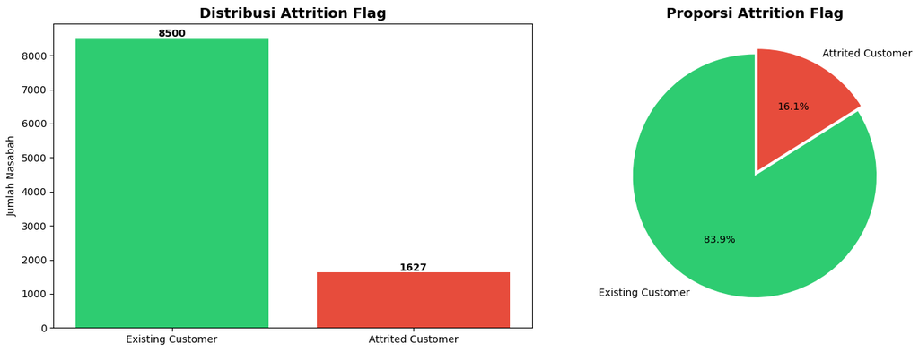

```
Rasio Existing:Attrited = 8500:1627
Persentase Churn: 16.1%
```

```python
# Definisi warna
green = '#2ecc71'
red = '#e74c3c'

# Distribusi target
fig, axes = plt.subplots(1, 2, figsize=(14, 5))

# Bar chart
target_counts = df['attrition_flag'].value_counts()
colors = [green if x == 'Existing Customer' else red for x in target_counts.index]
axes[0].bar(target_counts.index, target_counts.values, color=colors)
axes[0].set_title('Distribusi Attrition Flag', fontsize=14, fontweight='bold')
axes[0].set_ylabel('Jumlah Nasabah')
for i, v in enumerate(target_counts.values):
    axes[0].text(i, v + 50, str(v), ha='center', fontweight='bold')

# Pie chart
axes[1].pie(target_counts.values, labels=target_counts.index,
            autopct='%1.1f%%', colors=[green, red],
            startangle=90, explode=(0, 0.05))
axes[1].set_title('Proporsi Attrition Flag', fontsize=14, fontweight='bold')

plt.tight_layout()
plt.show()

print(f"\nRasio Existing:Attrited = {target_counts.values[0]}:{target_counts.values[1]}")
print(f"Persentase Churn: {target_counts.values[1]/target_counts.sum()*100:.1f}%")
```

#### Insight: Distribusi Target

Dataset menunjukkan **class imbalance** yang signifikan, dengan proporsi *Attrited Customer* jauh lebih kecil dibanding *Existing Customer*.

### 2.2 Feature Engineering untuk Visualisasi

Membuat fitur **khusus untuk visualisasi** agar distribusi usia lebih mudah dipahami. Fitur ini **tidak dimasukkan ke dalam model**.

```python
# Age segment
age_bins = [0, 30, 40, 50, 60, 100]
age_labels = ['<30', '30-39', '40-49', '50-59', '60+']
df['age_segment'] = pd.cut(df['customer_age'], bins=age_bins, labels=age_labels, right=False)
print("Age Segment Distribution:")
print(df['age_segment'].value_counts().sort_index())
```

```
Age Segment Distribution:
age_segment
<30       195
30-39    1841
40-49    4561
50-59    2998
60+       532
Name: count, dtype: int64
```

### 2.3 Analisis Distribusi & Outlier (Fitur Numerik)

Untuk setiap fitur numerik, kita visualisasikan: **Histogram + KDE**, **Q-Q Plot**, dan **Boxplot** untuk mendeteksi outlier dan memahami distribusi.

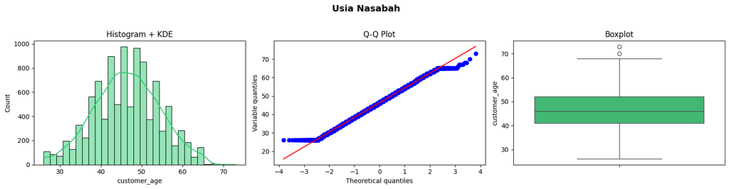

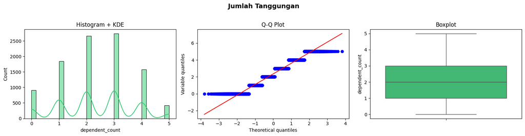

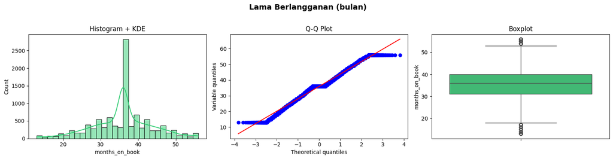

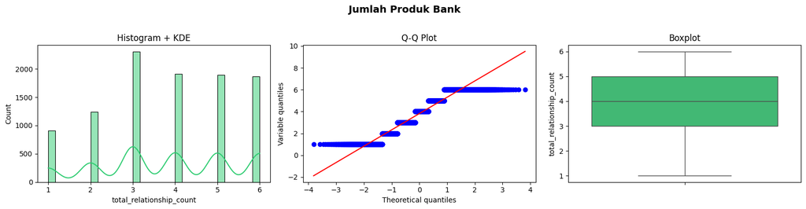

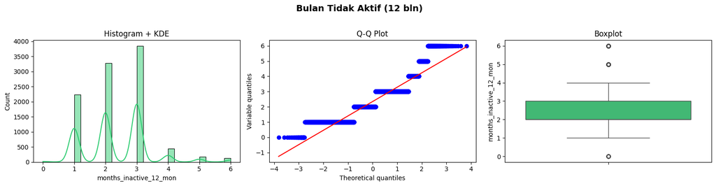

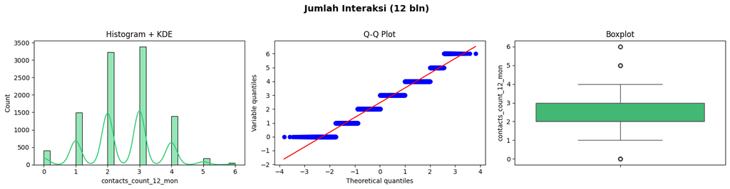

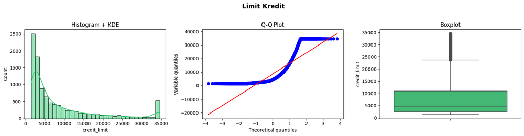

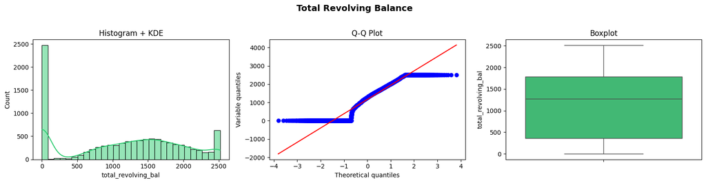

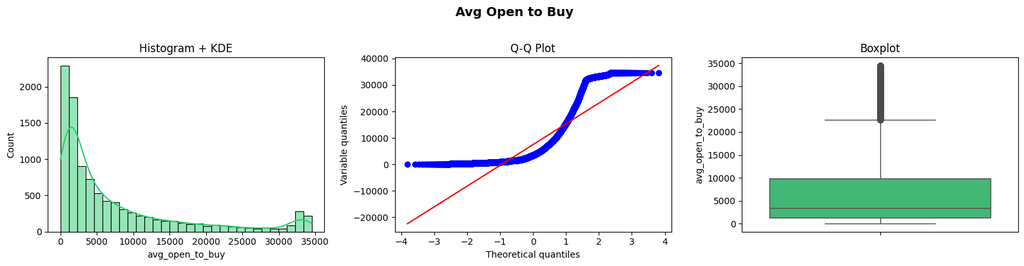

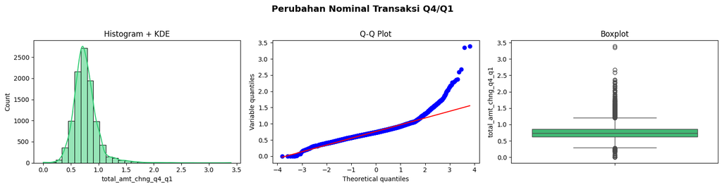

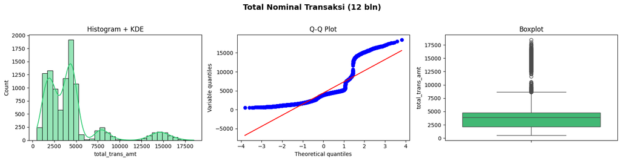

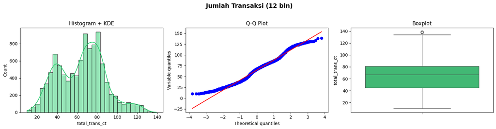

[2 more figures not shown]

```python
numerik_cols = ['customer_age', 'dependent_count', 'months_on_book',
                'total_relationship_count', 'months_inactive_12_mon',
                'contacts_count_12_mon', 'credit_limit', 'total_revolving_bal',
                'avg_open_to_buy', 'total_amt_chng_q4_q1', 'total_trans_amt',
                'total_trans_ct', 'total_ct_chng_q4_q1', 'avg_utilization_ratio']

nama_fitur = {
    'customer_age': 'Usia Nasabah',
    'dependent_count': 'Jumlah Tanggungan',
    'months_on_book': 'Lama Berlangganan (bulan)',
    'total_relationship_count': 'Jumlah Produk Bank',
    'months_inactive_12_mon': 'Bulan Tidak Aktif (12 bln)',
    'contacts_count_12_mon': 'Jumlah Interaksi (12 bln)',
    'credit_limit': 'Limit Kredit',
    'total_revolving_bal': 'Total Revolving Balance',
    'avg_open_to_buy': 'Avg Open to Buy',
    'total_amt_chng_q4_q1': 'Perubahan Nominal Transaksi Q4/Q1',
    'total_trans_amt': 'Total Nominal Transaksi (12 bln)',
    'total_trans_ct': 'Jumlah Transaksi (12 bln)',
    'total_ct_chng_q4_q1': 'Perubahan Jumlah Transaksi Q4/Q1',
    'avg_utilization_ratio': 'Rasio Pemakaian Kartu Kredit'
}

def check_plot(df, columns):
    for variable in columns:
        plt.figure(figsize=(16, 4))
        plt.suptitle(f' {nama_fitur.get(variable, variable)}', fontsize=14, fontweight='bold', y=1.02)

        # Histogram
        plt.subplot(1, 3, 1)
        sns.histplot(df[variable], bins=30, kde=True, color=green)
        plt.title('Histogram + KDE')
        plt.xlabel(variable)

        # Q-Q Plot
        plt.subplot(1, 3, 2)
        stats.probplot(df[variable], dist="norm", plot=plt)
        plt.title('Q-Q Plot')
        plt.ylabel('Variable quantiles')

        # Box Plot
        plt.subplot(1, 3, 3)
        sns.boxplot(y=df[variable], color='#2ecc71')
        plt.title('Boxplot')

        plt.tight_layout()
        plt.show()

check_plot(df, numerik_cols)
```

```python
# Cek outlier secara numerik dengan IQR
print("=== Cek Outlier (IQR Method) ===\n")
for col in numerik_cols:
    Q1 = df[col].quantile(0.25)
    Q3 = df[col].quantile(0.75)
    IQR = Q3 - Q1
    lower = Q1 - 1.5 * IQR
    upper = Q3 + 1.5 * IQR
    outliers = df[(df[col] < lower) | (df[col] > upper)]
    print(f"{col}:")
    print(f"  Q1={Q1:.2f}, Q3={Q3:.2f}, IQR={IQR:.2f}")
    print(f"  Batas bawah={lower:.2f}, Batas atas={upper:.2f}")
    print(f"  Jumlah outlier: {len(outliers)}")
    print()
```

```
=== Cek Outlier (IQR Method) ===

customer_age:
  Q1=41.00, Q3=52.00, IQR=11.00
  Batas bawah=24.50, Batas atas=68.50
  Jumlah outlier: 2

dependent_count:
  Q1=1.00, Q3=3.00, IQR=2.00
  Batas bawah=-2.00, Batas atas=6.00
  Jumlah outlier: 0

months_on_book:
  Q1=31.00, Q3=40.00, IQR=9.00
  Batas bawah=17.50, Batas atas=53.50
  Jumlah outlier: 386

total_relationship_count:
  Q1=3.00, Q3=5.00, IQR=2.00
  Batas bawah=0.00, Batas atas=8.00
  Jumlah outlier: 0

months_inactive_12_mon:
  Q1=2.00, Q3=3.00, IQR=1.00
  Batas bawah=0.50, Batas atas=4.50
  Jumlah outlier: 331

contacts_count_12_mon:
  Q1=2.00, Q3=3.00, IQR=1.00
  Batas bawah=0.50, Batas atas=4.50
  Jumlah outlier: 629

credit_limit:
  Q1=2555.00, Q3=11067.50, IQR=8512.50
  Batas bawah=-10213.75, Batas atas=23836.25
  Jumlah outlier: 984

total_revolving_bal:
  Q1=359.00, Q3=1784.00, IQR=1425.00
  Batas bawah=-1778.50, Batas atas=3921.50
```

[output cut: 16 more lines]

```

total_trans_ct:
  Q1=45.00, Q3=81.00, IQR=36.00
  Batas bawah=-9.00, Batas atas=135.00
  Jumlah outlier: 2

total_ct_chng_q4_q1:
  Q1=0.58, Q3=0.82, IQR=0.24
  Batas bawah=0.23, Batas atas=1.17
  Jumlah outlier: 396

avg_utilization_ratio:
  Q1=0.02, Q3=0.50, IQR=0.48
  Batas bawah=-0.70, Batas atas=1.22
  Jumlah outlier: 0
```

#### Insight: Distribusi & Outlier

- **customer_age**: Distribusi mendekati normal, mayoritas nasabah di rentang 40–55 tahun.
- **credit_limit, avg_open_to_buy**: Distribusi right-skewed dengan outlier signifikan. Ini wajar untuk data finansial.
- **total_trans_amt, total_trans_ct**: Distribusi bimodal, mengindikasikan adanya dua kelompok nasabah dengan perilaku transaksi berbeda — ini bisa menjadi signal penting untuk churn.
- **total_amt_chng_q4_q1, total_ct_chng_q4_q1**: Ada beberapa outlier ekstrem tapi tidak akan di-drop karena bisa jadi signal.

**So What?** Outlier tidak di-remove karena bisa memberikan informasi penting. Scaling akan dilakukan saat preprocessing untuk menormalkan distribusi sebelum modeling.

### 2.4 Analisis Churn Rate per Fitur

Analisis hubungan setiap fitur terhadap churn menggunakan horizontal stacked bar chart untuk fitur kategorik dan binned fitur numerik.

```python
def plot_churn_rate(df, feature, title, churn_col='attrition_flag'):
    """Plot 100% stacked horizontal bar chart churn rate per feature"""
    temp = df.groupby([feature, churn_col])['user_id'].count().reset_index(name='count')
    total_counts = temp.groupby(feature)['count'].transform('sum')
    temp['churn_percentage'] = round(temp['count'] / total_counts * 100, 1)
    temp.drop(columns=['count'], inplace=True)

    # Map label
    temp['churn_label'] = temp[churn_col].map(
        {'Existing Customer': 'No', 'Attrited Customer': 'Yes'}
    )

    fig = px.bar(temp,
                 x='churn_percentage',
                 y=feature,
                 color='churn_label',
                 color_discrete_map={'No': 'skyblue', 'Yes': 'salmon'},
                 orientation='h',
                 title=title,
                 text='churn_percentage',
                 labels={'churn_percentage': 'Percentage (%)', feature: feature})
    fig.update_layout(barmode='stack')
    fig.update_traces(textposition='inside', textfont=dict(size=11))
    fig.show()
```

```python
plot_churn_rate(df, 'age_segment', 'Churn Rate berdasarkan Segmen Usia')
```

#### Insight: Usia & Churn

Nasabah di segmen usia **50-59 dan 60+** cenderung memiliki churn rate yang lebih tinggi dibandingkan segmen yang lebih muda.

**So What?** Targetkan nasabah usia 50+ dengan program retensi khusus (loyalty program, personal relationship manager, dsb.) karena mereka paling berisiko churn.

```python
plot_churn_rate(df, 'gender', 'Churn Rate berdasarkan Gender')
```

#### Insight: Gender & Churn

Terdapat sedikit perbedaan churn rate antara gender M dan F, tetapi tidak terlalu signifikan.

**So What?** Gender bukan faktor utama dalam prediksi churn. Strategi retensi tidak perlu dibedakan secara signifikan berdasarkan gender saja.

```python
plot_churn_rate(df, 'education_level', 'Churn Rate berdasarkan Education Level')
```

#### Insight: Education Level & Churn

Kategori **Unknown** dan **Doctorate** memiliki churn rate yang relatif lebih tinggi. Hal ini menunjukkan bahwa status pada education bisa jadi **signal** yang relevan — bukan noise.

**So What?** Nasabah dengan education Unknown mungkin kurang engaged dengan bank (tidak mau mengisi data). Ini bisa menjadi indikator early warning untuk churn.

```python
plot_churn_rate(df, 'income_category', 'Churn Rate berdasarkan Income Category')
```

#### Insight: Income Category & Churn

Nasabah dengan kategori pendapatan **Unknown** dan **Less than $40K** memiliki churn rate yang lebih tinggi.

**So What?** Nasabah berpendapatan rendah dan yang tidak mengisi data pendapatan perlu mendapat perhatian khusus dari program retensi. Program loyalty berbasis reward yang mudah diakses bisa membantu.

```python
plot_churn_rate(df, 'card_category', 'Churn Rate berdasarkan Card Category')
```

#### Insight: Card Category & Churn

Mayoritas nasabah menggunakan kartu **Blue** (entry-level). Churn rate relatif merata di semua kategori kartu.

**So What?** Tipe kartu bukan pembeda utama churn. Namun, upgrade kartu bisa digunakan sebagai insentif retensi untuk nasabah yang berisiko churn.

```python
plot_churn_rate(df, 'marital_status', 'Churn Rate berdasarkan Marital Status')
```

#### Insight: Marital Status & Churn

Churn rate relatif merata di semua status pernikahan.

**So What?** Status pernikahan bukan faktor utama churn, tetapi tetap berguna sebagai salah satu variabel dalam model prediktif.

```python
plot_churn_rate(df, 'months_inactive_12_mon', 'Churn Rate berdasarkan Months Inactive (12 bulan)')
```

#### Insight: Months Inactive & Churn

Nasabah dengan **3+ bulan** tidak aktif dalam 12 bulan terakhir memiliki churn rate yang **jauh lebih tinggi**.

**So What?** Bulan tidak aktif adalah salah satu prediktor churn terkuat. Bank harus mengimplementasikan **early warning system** ketika nasabah tidak aktif selama 2 bulan berturut-turut dan segera melakukan outreach.

```python
plot_churn_rate(df, 'contacts_count_12_mon', 'Churn Rate berdasarkan Contacts Count (12 bulan)')
```

#### Insight: Contacts Count & Churn

Menariknya, nasabah dengan **lebih banyak interaksi/kontak** dengan bank justru memiliki churn rate yang **lebih tinggi**. Ini kontra-intuitif.

**So What?** Banyaknya kontak bukan berarti nasabah puas — malah bisa jadi indikasi nasabah yang sedang **komplain atau mengalami masalah**. Kualitas interaksi lebih penting dari kuantitas. Tim CS harus dilatih untuk mendeteksi keluhan terselubung.

```python
plot_churn_rate(df, 'total_relationship_count', 'Churn Rate berdasarkan Total Relationship Count (Jumlah Produk)')
```

#### Insight: Total Relationship Count & Churn

Nasabah dengan **sedikit produk** (1-2 produk) memiliki churn rate yang lebih tinggi. Semakin banyak produk yang digunakan, semakin kecil kemungkinan churn.

**So What?** Cross-selling dan bundling produk adalah strategi retensi efektif. Targetkan nasabah dengan 1-2 produk untuk di-upsell produk tambahan.

### 2.5 Heatmap Korelasi & VIF Analysis

Mengecek korelasi antar fitur numerik dan multicollinearity. **Tidak ada fitur yang di-drop**, user akan cek manual.

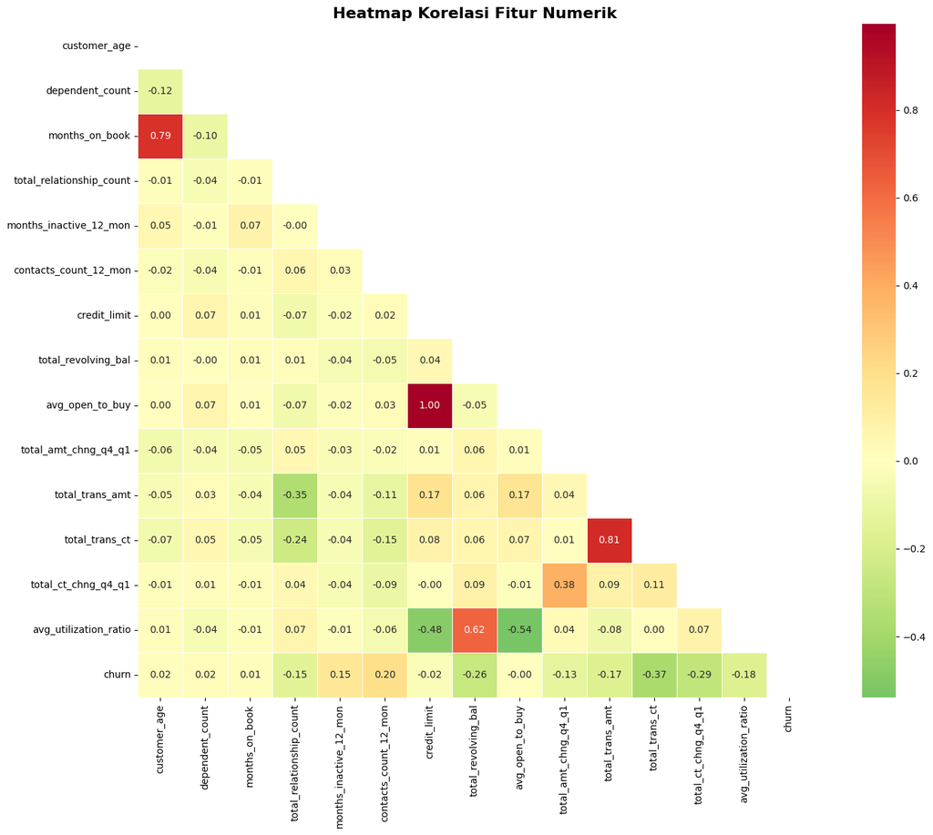

```python
# Encode target untuk korelasi
df_corr = df.copy()
df_corr['churn'] = df_corr['attrition_flag'].map({'Existing Customer': 0, 'Attrited Customer': 1})

# Heatmap
corr_cols = numerik_cols + ['churn']
corr_matrix = df_corr[corr_cols].corr()

plt.figure(figsize=(16, 12))
mask = np.triu(np.ones_like(corr_matrix, dtype=bool))
sns.heatmap(corr_matrix, mask=mask, annot=True, fmt='.2f', cmap='RdYlGn_r',
            center=0, square=True, linewidths=0.5)
plt.title('Heatmap Korelasi Fitur Numerik', fontsize=16, fontweight='bold')
plt.tight_layout()
plt.show()
```

```python
# Cek korelasi antara total_trans_ct dan total_trans_amt
corr_val = df_corr['total_trans_ct'].corr(df_corr['total_trans_amt'])
print(f"Korelasi total_trans_ct vs total_trans_amt: {corr_val:.4f}")

# Cek credit_limit vs avg_open_to_buy
corr_val2 = df_corr['credit_limit'].corr(df_corr['avg_open_to_buy'])
print(f"Korelasi credit_limit vs avg_open_to_buy: {corr_val2:.4f}")
```

```
Korelasi total_trans_ct vs total_trans_amt: 0.8072
Korelasi credit_limit vs avg_open_to_buy: 0.9960
```

```python
# VIF Analysis
vif_data = df_corr[numerik_cols].copy()
vif_data = add_constant(vif_data)
vif_results = pd.DataFrame()
vif_results['Feature'] = vif_data.columns
vif_results['VIF'] = [variance_inflation_factor(vif_data.values, i) for i in range(vif_data.shape[1])]
vif_results = vif_results[vif_results['Feature'] != 'const'].sort_values('VIF', ascending=False)
print("\nVIF Analysis (Variance Inflation Factor):")
print(vif_results.to_string(index=False))
```

```
VIF Analysis (Variance Inflation Factor):
                 Feature      VIF
            credit_limit      inf
     total_revolving_bal      inf
         avg_open_to_buy      inf
         total_trans_amt 3.263320
          total_trans_ct 3.024481
   avg_utilization_ratio 2.900014
            customer_age 2.675596
          months_on_book 2.658376
     total_ct_chng_q4_q1 1.208277
    total_amt_chng_q4_q1 1.192111
total_relationship_count 1.155622
   contacts_count_12_mon 1.037201
         dependent_count 1.028368
  months_inactive_12_mon 1.011255
```

#### Insight: Korelasi & Multicollinearity

**Temuan Kritis dari VIF & Korelasi:**

[output not shown]

**Keputusan: Drop `avg_open_to_buy`**

Alasannya ada 3:

1. **Derived feature**: `avg_open_to_buy = credit_limit - current_balance`. Ia bukan informasi baru — hanya transformasi aritmatika dari `credit_limit`.
2. **`credit_limit` lebih original**: Limit adalah keputusan underwriting bank yang mencerminkan profil risiko nasabah, sehingga lebih meaningful sebagai fitur.
3. **VIF tak terhingga**: Dalam model linear (Logistic Regression), keduanya tidak bisa coexist — koefisien akan tidak stabil dan confidence interval meledak. Untuk XGBoost sekalipun, adanya fitur redundan membagi feature importance secara artifisial.

**So What?** Drop `avg_open_to_buy` di tahap preprocessing. Utilization nasabah sudah diwakili oleh `avg_utilization_ratio` dan `total_revolving_bal`.

## 3. Data Preprocessing & Encoding

Tahap ini mencakup encoding variabel kategorik, scaling fitur numerik, dan persiapan data untuk modeling.

```python
# Copy dataframe untuk preprocessing
df_model = df.copy()

# Drop kolom yang tidak diperlukan:
# - user_id, age_segment: bukan fitur prediktif
# - avg_open_to_buy: DROPPED karena multicollinearity (derived dari credit_limit, VIF → ∞)
df_model.drop(columns=['user_id', 'age_segment', 'avg_open_to_buy'], inplace=True)

print(f"Shape sebelum preprocessing: {df_model.shape}")
print(f"Kolom: {list(df_model.columns)}")
```

```
Shape sebelum preprocessing: (10127, 19)
Kolom: ['attrition_flag', 'customer_age', 'gender', 'dependent_count', 'education_level', 'marital_status', 'income_category', 'card_category', 'months_on_book', 'total_relationship_count', 'months_inactive_12_mon', 'contacts_count_12_mon', 'credit_limit', 'total_revolving_bal', 'total_amt_chng_q4_q…
```

```python
# VIF Analysis
num = ['customer_age', 'dependent_count', 'months_on_book',
                'total_relationship_count', 'months_inactive_12_mon',
                'contacts_count_12_mon', 'credit_limit', 'total_revolving_bal',
                'total_amt_chng_q4_q1', 'total_trans_amt',
                'total_ct_chng_q4_q1', 'avg_utilization_ratio']
vif_data = df_model[num].copy()
vif_data = add_constant(vif_data)
vif_results = pd.DataFrame()
vif_results['Feature'] = vif_data.columns
vif_results['VIF'] = [variance_inflation_factor(vif_data.values, i) for i in range(vif_data.shape[1])]
vif_results = vif_results[vif_results['Feature'] != 'const'].sort_values('VIF', ascending=False)
print("\nVIF Analysis (Variance Inflation Factor):")
print(vif_results.to_string(index=False))
```

```
VIF Analysis (Variance Inflation Factor):
                 Feature      VIF
   avg_utilization_ratio 2.871448
            customer_age 2.670251
          months_on_book 2.657373
     total_revolving_bal 2.215582
            credit_limit 1.764343
         total_trans_amt 1.203147
     total_ct_chng_q4_q1 1.200129
    total_amt_chng_q4_q1 1.184117
total_relationship_count 1.150232
   contacts_count_12_mon 1.028175
         dependent_count 1.026121
  months_inactive_12_mon 1.010884
```

### 3.1 Target Encoding

```python
# Target encoding: Existing Customer = 0, Attrited Customer = 1
df_model['attrition_flag'] = df_model['attrition_flag'].map({
    'Existing Customer': 0,
    'Attrited Customer': 1
})
print("Target distribution setelah encoding:")
print(df_model['attrition_flag'].value_counts())
```

```
Target distribution setelah encoding:
attrition_flag
0    8500
1    1627
Name: count, dtype: int64
```

### 3.2 Ordinal Encoding

```python
# Income Category (ordinal)
income_order = ['Unknown', 'Less than $40K', '$40K - $60K', '$60K - $80K', '$80K - $120K', '$120K +']
income_map = {k: v for v, k in enumerate(income_order)}
df_model['income_category'] = df_model['income_category'].map(income_map)

# Education Level (ordinal)
edu_order = ['Unknown', 'Uneducated', 'High School', 'College', 'Graduate', 'Post-Graduate', 'Doctorate']
edu_map = {k: v for v, k in enumerate(edu_order)}
df_model['education_level'] = df_model['education_level'].map(edu_map)

# Card Category (ordinal)
card_order = ['Blue', 'Silver', 'Gold', 'Platinum']
card_map = {k: v+1 for v, k in enumerate(card_order)}
df_model['card_category'] = df_model['card_category'].map(card_map)

print("Ordinal encoding completed.")
print(f"Income unique: {sorted(df_model['income_category'].unique())}")
print(f"Education unique: {sorted(df_model['education_level'].unique())}")
print(f"Card unique: {sorted(df_model['card_category'].unique())}")
```

```
Ordinal encoding completed.
Income unique: [np.int64(0), np.int64(1), np.int64(2), np.int64(3), np.int64(4), np.int64(5)]
Education unique: [np.int64(0), np.int64(1), np.int64(2), np.int64(3), np.int64(4), np.int64(5), np.int64(6)]
Card unique: [np.int64(1), np.int64(2), np.int64(3), np.int64(4)]
```

### 3.3 Binary & One-Hot Encoding

```python
# Gender: Binary encoding (M=1, F=0)
df_model['gender'] = df_model['gender'].map({'M': 1, 'F': 0})

# Marital Status: One-hot encoding
df_model = pd.get_dummies(df_model, columns=['marital_status'], prefix='marital', drop_first=False, dtype=int)

print("Encoding completed.")
print(f"Shape setelah encoding: {df_model.shape}")
print(f"Kolom: {list(df_model.columns)}")
```

```
Encoding completed.
Shape setelah encoding: (10127, 22)
Kolom: ['attrition_flag', 'customer_age', 'gender', 'dependent_count', 'education_level', 'income_category', 'card_category', 'months_on_book', 'total_relationship_count', 'months_inactive_12_mon', 'contacts_count_12_mon', 'credit_limit', 'total_revolving_bal', 'total_amt_chng_q4_q1', 'total_trans_a…
```

### 3.4 Feature & Target Split → Train/Test Split → Scaling

> **Penting — Urutan yang Benar untuk Mencegah Data Leakage:** Scaling **wajib** dilakukan SETELAH split. Scaler harus di-`fit` hanya pada data training, lalu di-`transform` ke test data. Jika scaling dilakukan sebelum split, statistik (mean/std) dari data test akan "bocor" ke proses training → model terlihat overfit padahal sebenarnya sudah melihat informasi test set.

```python
# Pisahkan fitur dan target (belum di-scale)
X = df_model.drop(columns=['attrition_flag'])
y = df_model['attrition_flag']

print(f"X shape: {X.shape}")
print(f"y shape: {y.shape}")
print(f"\nTarget distribution:")
print(y.value_counts())
```

```
X shape: (10127, 21)
y shape: (10127,)

Target distribution:
attrition_flag
0    8500
1    1627
Name: count, dtype: int64
```

## 4. Data Splitting

Split data menjadi **Train (80%)** dan **Test (20%)** dengan stratified sampling pada target.

```python
# Step 1: Split data dulu SEBELUM scaling (hindari data leakage)
X_train, X_test, y_train, y_test = train_test_split(
    X, y, test_size=0.2, random_state=RANDOM_STATE, stratify=y
)

print(f"X_train shape: {X_train.shape}")
print(f"X_test shape:  {X_test.shape}")
print(f"\nTrain target distribution:")
print(y_train.value_counts(normalize=True).round(4))
print(f"\nTest target distribution:")
print(y_test.value_counts(normalize=True).round(4))

# Step 2: Scaling SETELAH split — fit HANYA pada training data
scaler = StandardScaler()
X_train = pd.DataFrame(scaler.fit_transform(X_train), columns=X_train.columns, index=X_train.index)
X_test  = pd.DataFrame(scaler.transform(X_test),      columns=X_test.columns,  index=X_test.index)

print("\nScaling selesai. Statistik scaler (dari training data):")
print(f"  Mean range : [{scaler.mean_.min():.2f}, {scaler.mean_.max():.2f}]")
print(f"  Std range  : [{scaler.scale_.min():.2f}, {scaler.scale_.max():.2f}]")
```

```
X_train shape: (8101, 21)
X_test shape:  (2026, 21)

Train target distribution:
attrition_flag
0    0.8393
1    0.1607
Name: proportion, dtype: float64

Test target distribution:
attrition_flag
0    0.8396
1    0.1604
Name: proportion, dtype: float64

Scaling selesai. Statistik scaler (dari training data):
  Mean range : [0.07, 8580.07]
  Std range  : [0.22, 9031.81]
```

## 5. Pemodelan Machine Learning

**Strategi:**

### 5.1 Baseline Model: Logistic Regression

```python
# Baseline: Logistic Regression
lr_model = LogisticRegression(
    class_weight='balanced',
    max_iter=1000,
    random_state=RANDOM_STATE
)

# Cross-Validation
cv = StratifiedKFold(n_splits=5, shuffle=True, random_state=RANDOM_STATE)

lr_cv_scores = {
    'accuracy': cross_val_score(lr_model, X_train, y_train, cv=cv, scoring='accuracy'),
    'recall': cross_val_score(lr_model, X_train, y_train, cv=cv, scoring='recall'),
    'f1': cross_val_score(lr_model, X_train, y_train, cv=cv, scoring='f1'),
    'roc_auc': cross_val_score(lr_model, X_train, y_train, cv=cv, scoring='roc_auc')
}

print("=== Logistic Regression — Cross-Validation (5-Fold) ===")
for metric, scores in lr_cv_scores.items():
    print(f"{metric:>10s}: {scores.mean():.4f} (+/- {scores.std():.4f})")

# Fit on full training set
lr_model.fit(X_train, y_train)
lr_pred = lr_model.predict(X_test)
lr_pred_proba = lr_model.predict_proba(X_test)[:, 1]

print("\n=== Logistic Regression — Test Set ===")
print(classification_report(y_test, lr_pred, target_names=['Existing', 'Attrited']))
```

```
=== Logistic Regression — Cross-Validation (5-Fold) ===
  accuracy: 0.8494 (+/- 0.0083)
    recall: 0.8495 (+/- 0.0192)
        f1: 0.6447 (+/- 0.0133)
   roc_auc: 0.9265 (+/- 0.0069)

=== Logistic Regression — Test Set ===
              precision    recall  f1-score   support

    Existing       0.96      0.86      0.91      1701
    Attrited       0.53      0.82      0.64       325

    accuracy                           0.85      2026
   macro avg       0.74      0.84      0.77      2026
weighted avg       0.89      0.85      0.86      2026
```

### 5.2 LazyPredict — Quick Benchmarking (Analisis Saja)

```python
# from lazypredict.Supervised import LazyClassifier

# lazy_clf = LazyClassifier(verbose=0, ignore_warnings=True, custom_metric=None)
# lazy_models, lazy_predictions = lazy_clf.fit(X_train, X_test, y_train, y_test)

# print("=== LazyPredict — Top 15 Models ===")
# lazy_models.head(15)
```

### 5.3 Model Utama: XGBoost

```python
# Hitung scale_pos_weight
neg_count = (y_train == 0).sum()
pos_count = (y_train == 1).sum()
scale_pos_weight = neg_count / pos_count
# scale_pos_weight = np.sqrt(neg_count / pos_count)
print(f"scale_pos_weight: {scale_pos_weight:.2f} (ratio {neg_count}:{pos_count})")

# XGBoost
xgb_model = xgb.XGBClassifier(
    scale_pos_weight=scale_pos_weight,
    n_estimators=100,
    max_depth=4,
    learning_rate=0.1,
    subsample=0.8,
    colsample_bytree=0.8,
    min_child_weight=10,
    reg_alpha=0.1,             # L1 regularization
    reg_lambda=1.5,
    random_state=RANDOM_STATE,
    eval_metric='logloss',
    use_label_encoder=False,
    # early_stopping_rounds=30
)

# Cross-Validation
xgb_cv_scores = {
    'accuracy': cross_val_score(xgb_model, X_train, y_train, cv=cv, scoring='accuracy'),
    'recall': cross_val_score(xgb_model, X_train, y_train, cv=cv, scoring='recall'),
    'f1': cross_val_score(xgb_model, X_train, y_train, cv=cv, scoring='f1'),
    'roc_auc': cross_val_score(xgb_model, X_train, y_train, cv=cv, scoring='roc_auc')
}

print("\n=== XGBoost — Cross-Validation (5-Fold) ===")
for metric, scores in xgb_cv_scores.items():
    print(f"{metric:>10s}: {scores.mean():.4f} (+/- {scores.std():.4f})")

# Fit on full training set
xgb_model.fit(X_train, y_train)
xgb_pred = xgb_model.predict(X_test)
xgb_pred_proba = xgb_model.predict_proba(X_test)[:, 1]

print("\n=== XGBoost — Test Set ===")
print(classification_report(y_test, xgb_pred, target_names=['Existing', 'Attrited']))
```

```
scale_pos_weight: 5.22 (ratio 6799:1302)

=== XGBoost — Cross-Validation (5-Fold) ===
  accuracy: 0.9584 (+/- 0.0053)
    recall: 0.9478 (+/- 0.0086)
        f1: 0.8800 (+/- 0.0138)
   roc_auc: 0.9916 (+/- 0.0019)

=== XGBoost — Test Set ===
              precision    recall  f1-score   support

    Existing       0.99      0.96      0.98      1701
    Attrited       0.83      0.94      0.88       325

    accuracy                           0.96      2026
   macro avg       0.91      0.95      0.93      2026
weighted avg       0.96      0.96      0.96      2026
```

### 5.4 Perbandingan Model: Baseline vs XGBoost

```python
# Perbandingan metrik
comparison = pd.DataFrame({
    'Metric': ['Accuracy', 'Precision', 'Recall', 'F1-Score', 'ROC-AUC'],
    'Logistic Regression': [
        accuracy_score(y_test, lr_pred),
        precision_score(y_test, lr_pred),
        recall_score(y_test, lr_pred),
        f1_score(y_test, lr_pred),
        roc_auc_score(y_test, lr_pred_proba)
    ],
    'XGBoost': [
        accuracy_score(y_test, xgb_pred),
        precision_score(y_test, xgb_pred),
        recall_score(y_test, xgb_pred),
        f1_score(y_test, xgb_pred),
        roc_auc_score(y_test, xgb_pred_proba)
    ]
})
comparison = comparison.round(4)
print("=== Perbandingan Model ===")
print(comparison.to_string(index=False))
```

```
=== Perbandingan Model ===
   Metric  Logistic Regression  XGBoost
 Accuracy               0.8524   0.9595
Precision               0.5256   0.8311
   Recall               0.8215   0.9385
 F1-Score               0.6411   0.8815
  ROC-AUC               0.9200   0.9914
```

#### Insight: Perbandingan Baseline vs XGBoost

XGBoost menunjukkan performa yang **secara signifikan lebih baik** dibandingkan baseline Logistic Regression pada hampir semua metrik, terutama pada **Recall** dan **F1-Score** yang merupakan metrik prioritas.

**Kenapa pakai XGBoost meskipun lebih kompleks?** XGBoost tidak hanya memberikan akurasi lebih tinggi, tetapi juga jauh lebih baik dalam mendeteksi nasabah yang akan churn (Recall tinggi), yang merupakan prioritas bisnis utama. Selain itu, dengan SHAP kita tetap bisa mendapatkan interpretability yang tinggi.

```python
xgb_train_pred       = xgb_model.predict(X_train)
xgb_train_pred_proba = xgb_model.predict_proba(X_train)[:, 1]

metrics = {
    'Accuracy' : (accuracy_score(y_train, xgb_train_pred),
                  accuracy_score(y_test,  xgb_pred)),
    'Recall'   : (recall_score(y_train, xgb_train_pred),
                  recall_score(y_test,  xgb_pred)),
    'F1-Score' : (f1_score(y_train, xgb_train_pred),
                  f1_score(y_test,  xgb_pred)),
    'ROC-AUC'  : (roc_auc_score(y_train, xgb_train_pred_proba),
                  roc_auc_score(y_test,  xgb_pred_proba)),
}

print("=" * 45)
print(f"{'Metric':<12} {'Train':>10} {'Test':>10} {'Gap':>10}")
print("=" * 45)
for metric, (tr, te) in metrics.items():
    gap = tr - te
    flag = " ⚠️" if abs(gap) > 0.05 else " ✅"
    print(f"{metric:<12} {tr:>10.4f} {te:>10.4f} {gap:>+10.4f}{flag}")
print("=" * 45)
print("⚠️  = gap > 0.05 (indikasi overfit)")
print("✅  = gap ≤ 0.05 (aman)")
```

```
=============================================
Metric            Train       Test        Gap
=============================================
Accuracy         0.9723     0.9595    +0.0128 ✅
Recall           0.9846     0.9385    +0.0462 ✅
F1-Score         0.9197     0.8815    +0.0382 ✅
ROC-AUC          0.9973     0.9914    +0.0059 ✅
=============================================
⚠️  = gap > 0.05 (indikasi overfit)
✅  = gap ≤ 0.05 (aman)
```

[output not shown]

[output cut: 145 more lines]

[output not shown]

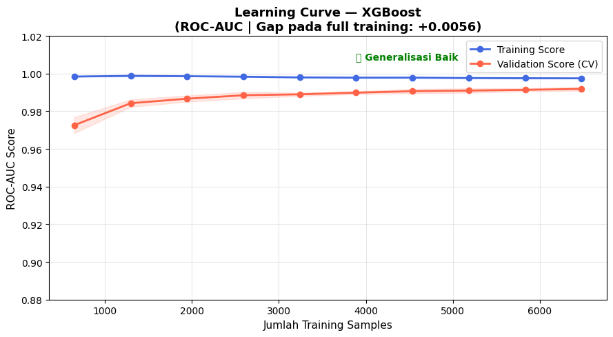

```
Train Score  (full data): 0.9975 ± 0.0002
Val Score    (full data): 0.9919 ± 0.0010
Gap                     : +0.0056
```

```python
from sklearn.model_selection import learning_curve

train_sizes, train_scores, val_scores = learning_curve(
    estimator=xgb_model,
    X=X_train,
    y=y_train,
    train_sizes=np.linspace(0.1, 1.0, 10),
    cv=5,
    scoring='roc_auc',
    n_jobs=-1,
    random_state=RANDOM_STATE
)

train_mean = train_scores.mean(axis=1)
train_std  = train_scores.std(axis=1)
val_mean   = val_scores.mean(axis=1)
val_std    = val_scores.std(axis=1)

fig, ax = plt.subplots(figsize=(9, 5))

ax.plot(train_sizes, train_mean, 'o-', color='royalblue',
        label='Training Score', linewidth=2)
ax.fill_between(train_sizes,
                train_mean - train_std,
                train_mean + train_std,
                alpha=0.15, color='royalblue')

ax.plot(train_sizes, val_mean, 'o-', color='tomato',
        label='Validation Score (CV)', linewidth=2)
ax.fill_between(train_sizes,
                val_mean - val_std,
                val_mean + val_std,
                alpha=0.15, color='tomato')

gap_final = train_mean[-1] - val_mean[-1]
ax.set_title(f'Learning Curve — XGBoost\n(ROC-AUC | Gap pada full training: {gap_final:+.4f})',
             fontsize=13, fontweight='bold')
ax.set_xlabel('Jumlah Training Samples', fontsize=11)
ax.set_ylabel('ROC-AUC Score', fontsize=11)
ax.legend(fontsize=10)
ax.set_ylim(0.88, 1.02)
ax.grid(True, alpha=0.3)

# Anotasi otomatis
if gap_final > 0.05:
    ax.text(0.55, 0.91, '⚠️ Mild Overfitting Terdeteksi',
            transform=ax.transAxes, color='tomato', fontsize=10, fontweight='bold')
else:
    ax.text(0.55, 0.91, '✅ Generalisasi Baik',
            transform=ax.transAxes, color='green', fontsize=10, fontweight='bold')

plt.tight_layout()
plt.show()

print(f"\nTrain Score  (full data): {train_mean[-1]:.4f} ± {train_std[-1]:.4f}")
print(f"Val Score    (full data): {val_mean[-1]:.4f} ± {val_std[-1]:.4f}")
print(f"Gap                     : {gap_final:+.4f}")
```

## 6. Evaluasi Model

Evaluasi mendalam menggunakan Confusion Matrix, ROC Curve, dan terutama **Precision-Recall Curve** untuk membuktikan model lebih baik dari tanpa model.

### 6.1 Confusion Matrix

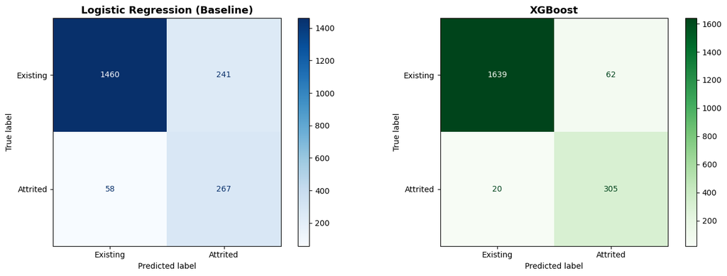

```python
fig, axes = plt.subplots(1, 2, figsize=(14, 5))

# LR Confusion Matrix
ConfusionMatrixDisplay.from_predictions(
    y_test, lr_pred, display_labels=['Existing', 'Attrited'],
    cmap='Blues', ax=axes[0]
)
axes[0].set_title('Logistic Regression (Baseline)', fontsize=13, fontweight='bold')

# XGBoost Confusion Matrix
ConfusionMatrixDisplay.from_predictions(
    y_test, xgb_pred, display_labels=['Existing', 'Attrited'],
    cmap='Greens', ax=axes[1]
)
axes[1].set_title('XGBoost', fontsize=13, fontweight='bold')

plt.tight_layout()
plt.show()
```

### 6.2 ROC Curve

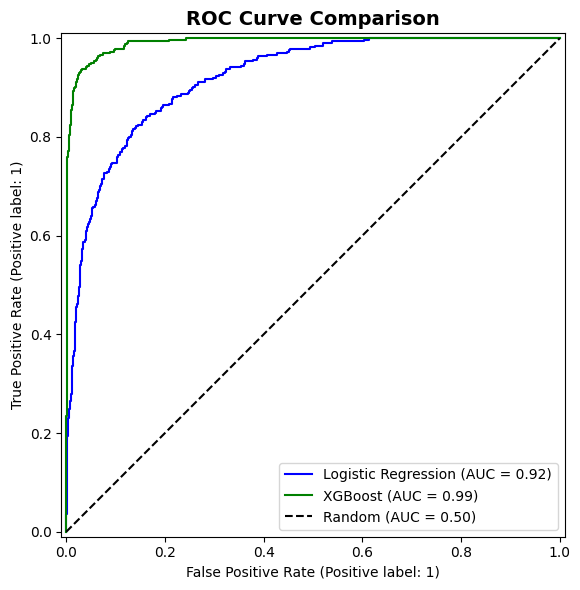

```python
fig, ax = plt.subplots(figsize=(8, 6))

RocCurveDisplay.from_predictions(y_test, lr_pred_proba, name='Logistic Regression', ax=ax, color='blue')
RocCurveDisplay.from_predictions(y_test, xgb_pred_proba, name='XGBoost', ax=ax, color='green')

ax.plot([0, 1], [0, 1], 'k--', label='Random (AUC = 0.50)')
ax.set_title('ROC Curve Comparison', fontsize=14, fontweight='bold')
ax.legend(loc='lower right')
plt.tight_layout()
plt.show()
```

### 6.3 Precision-Recall Curve

Ini adalah metrik kunci untuk membuktikan bahwa model yang digunakan **lebih baik** dalam mengidentifikasi customer yang akan churn dibandingkan tanpa model.

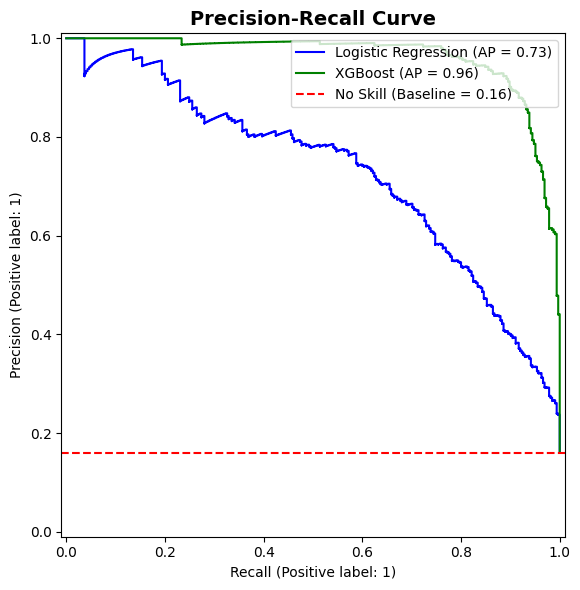

```
Average Precision - Logistic Regression: 0.7300
Average Precision - XGBoost: 0.9628
No-Skill Baseline: 0.1604
```

```python
fig, ax = plt.subplots(figsize=(8, 6))

PrecisionRecallDisplay.from_predictions(y_test, lr_pred_proba, name='Logistic Regression', ax=ax, color='blue')
PrecisionRecallDisplay.from_predictions(y_test, xgb_pred_proba, name='XGBoost', ax=ax, color='green')

# Baseline (no skill)
no_skill = y_test.sum() / len(y_test)
ax.axhline(y=no_skill, color='red', linestyle='--', label=f'No Skill (Baseline = {no_skill:.2f})')

ax.set_title('Precision-Recall Curve', fontsize=14, fontweight='bold')
ax.legend(loc='upper right')
plt.tight_layout()
plt.show()

# AP Score
lr_ap = average_precision_score(y_test, lr_pred_proba)
xgb_ap = average_precision_score(y_test, xgb_pred_proba)
print(f"Average Precision - Logistic Regression: {lr_ap:.4f}")
print(f"Average Precision - XGBoost: {xgb_ap:.4f}")
print(f"No-Skill Baseline: {no_skill:.4f}")
```

#### Insight: Evaluasi Model

- **Precision-Recall Curve** menunjukkan bahwa XGBoost jauh di atas garis *No Skill*, membuktikan bahwa model memberikan prediksi yang **jauh lebih baik** dibandingkan tanpa model.
- **ROC-AUC** XGBoost juga signifikan lebih tinggi dari baseline, menunjukkan kemampuan diskriminasi yang baik.
- Confusion Matrix menunjukkan XGBoost memiliki **lebih sedikit False Negatives** (nasabah churn yang tidak terdeteksi), yang krusial untuk use case ini.

**So What?** Model XGBoost siap digunakan secara operasional. Dengan precision-recall curve yang jauh di atas baseline, stakeholder dapat yakin bahwa investasi dalam model prediksi ini memberikan nilai tambah signifikan dibandingkan tanpa model.

## 7. Analisis Interpretabilitas Model (SHAP)

Karena XGBoost adalah model **non-interpretable**, kita menggunakan **SHAP (SHapley Additive exPlanations)** untuk memahami kontribusi setiap fitur terhadap prediksi churn.

**Goals:** Memahami faktor-faktor yang berkontribusi terhadap churn dan memastikan model memberikan insight yang dapat digunakan untuk pengambilan keputusan bisnis.

```python
# SHAP Explainer
explainer = shap.TreeExplainer(xgb_model)
shap_values = explainer.shap_values(X_test)
```

### 7.1 SHAP Summary Plot (Global Feature Importance)

Menunjukkan fitur mana yang paling berpengaruh terhadap prediksi churn secara keseluruhan.

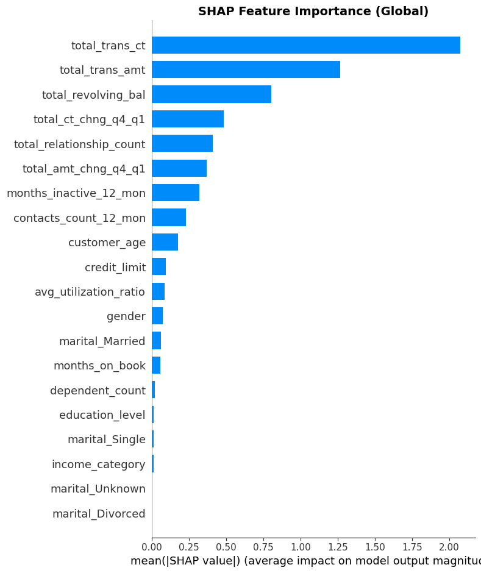

```python
plt.figure(figsize=(12, 8))
shap.summary_plot(shap_values, X_test, plot_type='bar', show=False)
plt.title('SHAP Feature Importance (Global)', fontsize=14, fontweight='bold')
plt.tight_layout()
plt.show()
```

### 7.2 SHAP Summary Plot (Beeswarm)

Menunjukkan arah pengaruh setiap fitur: apakah nilai tinggi suatu fitur meningkatkan atau menurunkan risiko churn.

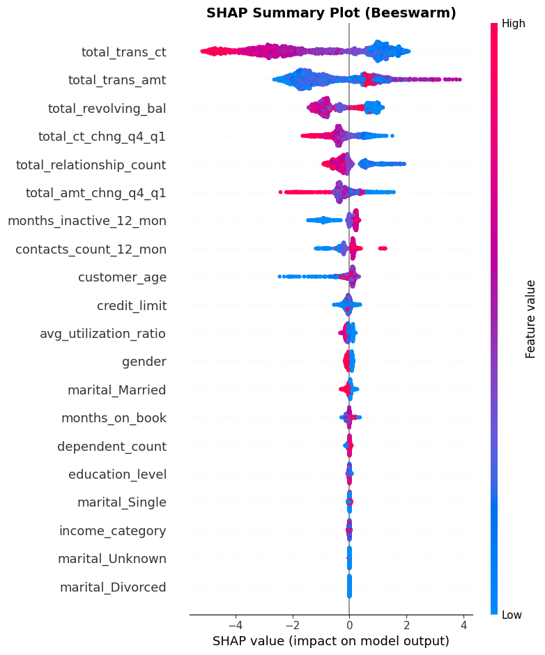

```python
plt.figure(figsize=(12, 8))
shap.summary_plot(shap_values, X_test, show=False)
plt.title('SHAP Summary Plot (Beeswarm)', fontsize=14, fontweight='bold')
plt.tight_layout()
plt.show()
```

### 7.3 SHAP Dependence Plot (Top 3 Features)

Analisis lebih dalam terhadap 3 fitur paling berpengaruh.

```
Top 3 Features: ['total_trans_ct', 'total_trans_amt', 'total_revolving_bal']
```

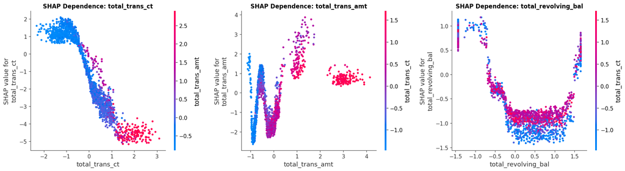

```python
# Identifikasi top 3 fitur
mean_shap = np.abs(shap_values).mean(axis=0)
top_features = X_test.columns[np.argsort(mean_shap)[::-1][:3]]
print(f"Top 3 Features: {list(top_features)}")

fig, axes = plt.subplots(1, 3, figsize=(18, 5))
for i, feat in enumerate(top_features):
    shap.dependence_plot(feat, shap_values, X_test, ax=axes[i], show=False)
    axes[i].set_title(f'SHAP Dependence: {feat}', fontsize=12, fontweight='bold')
plt.tight_layout()
plt.show()
```

## 🔍 Insight & Rekomendasi Bisnis — Top 3 Fitur Churn

Berdasarkan SHAP analysis, tiga fitur yang paling berkontribusi terhadap prediksi churn adalah `total_trans_ct`, `total_trans_amt`, dan `total_revolving_bal`. Berikut insight dan rekomendasi bisnis dari masing-masing fitur.

## 📊 Insight Top 3 Fitur

### 1. Total Transaction Count (`total_trans_ct`)

Frekuensi transaksi adalah **sinyal engagement terkuat** di seluruh model — gap SHAP-nya mencapai -4 hingga +2, jauh lebih besar dari fitur lain manapun.

- **Nasabah dengan transaksi rendah → sangat berisiko churn**
- **Nasabah dengan transaksi tinggi → diprediksi kuat untuk retain**

Nasabah yang jarang bertransaksi menunjukkan rendahnya ketergantungan terhadap produk bank. Tidak ada kebiasaan yang terbentuk, sehingga tidak ada barrier untuk beralih ke kompetitor.

### 2. Total Transaction Amount (`total_trans_amt`)

Nominal transaksi melengkapi frekuensi — keduanya membawa informasi yang berbeda dan sama-sama krusial.

- **Nasabah dengan nominal transaksi rendah → cenderung stay/retain**
- **Nasabah dengan nominal transaksi sangat tinggi → berisiko churn**

Ekor kanan berwarna merah yang panjang pada SHAP plot menunjukkan bahwa **nasabah high-spending cenderung berpotensi churn**, Ini adalah tipe nasabah "transaksional" yang nggak punya emotional attachment atau habit harian sama produk

### 3. Total Revolving Balance (`total_revolving_bal`)

Temuan ini counterintuitive namun logis secara bisnis.

- **Nasabah dengan revolving balance rendah (mendekati nol) → berisiko churn**
- **Nasabah dengan balance lebih tinggi → cenderung bertahan**

Nasabah yang tidak carry over balance antar bulan tidak memanfaatkan fasilitas kredit secara aktif — mereka tidak "terikat" secara finansial dengan bank. Tidak ada outstanding yang perlu dikelola, sehingga tidak ada barrier untuk menutup akun dan pindah ke kompetitor.

### Profil Nasabah Berisiko Tinggi

Kombinasi ketiga fitur menghasilkan profil churn yang paling actionable:

> **Nasabah berisiko tinggi = `trans_ct` rendah + `trans_amt` tinggi + `revolving_bal` rendah**

## 💡 Rekomendasi Bisnis

### 1. 🎯 Program Aktivasi Transaksi

**Target:** Nasabah dengan `total_trans_ct` rendah (< 40 transaksi/tahun)

Buat program yang mendorong **frekuensi** transaksi, bukan hanya nominal:

- Cashback per transaksi (bukan per nominal)
- Reward point yang accumulate dari jumlah swipe
- Challenge "transaksi X kali bulan ini dapat bonus"

Tujuannya membentuk **kebiasaan pakai kartu** secara konsisten, karena kebiasaan adalah barrier churn yang paling kuat.

### 2. 💰 Spending Incentive untuk Nasabah Low-Amount

Tawarkan merchant partnership dengan diskon di kategori **everyday spending**:

- Groceries & supermarket
- Transportasi & commute
- Makan & F&B

Nasabah low-amount butuh alasan untuk pakai kartu di pengeluaran harian, bukan luxury. Kalau kartu ini menjadi kartu utama untuk kebutuhan sehari-hari, churn rate akan turun secara organik.

### 3. 🔗 Dorong Utilisasi Kredit yang Sehat

**Target:** Nasabah dengan `total_revolving_bal` mendekati nol

Ciptakan **financial tie** yang mendorong nasabah carry balance secara sehat:

- Program cicilan 0% untuk pembelian tertentu
- Fitur "pay later" dengan bunga kompetitif
- Penawaran limit kredit increase untuk mendorong utilisasi

Tujuannya bukan membebani nasabah, melainkan menciptakan keterikatan finansial yang membuat mereka punya alasan untuk tetap aktif mengelola akun.

### 4. 📊 Early Warning System — Churn Risk Score

**Ini yang paling actionable jangka pendek** karena bisa diimplementasi dengan data yang sudah ada tanpa perlu infrastruktur baru.

## 8. Dokumentasi & Rekomendasi Bisnis

### 8.1 Ringkasan Proses Analisis

[output not shown]

### 8.3 Rekomendasi Bisnis

1. **Implementasi Early Warning System** — Monitor penurunan frekuensi transaksi (total_trans_ct) secara berkala sebagai indikator utama perilaku nasabah
2. **Program Retensi Berbasis Engagement** — Fokuskan program loyalty/reward pada peningkatan frekuensi transaksi, bukan hanya nominal. Nasabah yang terbiasa bertransaksi secara konsisten terbukti jauh lebih sulit untuk churn.
3. **Dorong Utilisasi Fasilitas Kredit** — Nasabah dengan revolving balance rendah adalah kelompok berisiko tinggi. Tawarkan program cicilan 0% atau fitur pay later untuk menciptakan keterikatan finansial yang sehat.
4. **Proactive Outreach untuk Nasabah Inaktif** — Nasabah dengan bulan inaktif tinggi perlu segera dihubungi oleh relationship manager sebelum keputusan churn terjadi.
5. **Cross-selling Strategy** — Nasabah dengan jumlah produk sedikit cenderung memiliki engagement lebih rendah. Tawarkan produk tambahan sebagai anchor untuk meningkatkan stickiness, namun pastikan relevan dengan kebutuhan nasabah.
6. **Data Completeness as Signal** — Nasabah dengan data tidak lengkap (income/education Unknown) menunjukkan kecenderungan churn lebih tinggi secara deskriptif. Gunakan ini sebagai salah satu variabel tambahan dalam early warning system.

### Reflection Questions

1. Mengapa eksplorasi data (mis. analisis usia, pendidikan, gender) penting sebelum membangun model prediksi churn, dan bagaimana temuan EDA dapat mempengaruhi pemilihan fitur serta performa model? Jawab dengan contoh konkret dari dataset (mis. kelompok usia atau tingkat pendidikan yang berisiko tinggi).

Mengapa penting adalah agar kita bisa melihat pola orang yang churn dan juga melihat korelasi dari ciri-ciri orang yang mungkin memiliki tingkat churn yang tinggi. Setelah kita mengetahui hal-hal tersebut, kita bisa memilih atau menyeleksi fitur mana yang sekiranya paling berpengaruh terhadap churn untuk keperluan modeling.

Selain itu, EDA juga membantu kita mendeteksi masalah data sejak awal, seperti distribusi yang skewed, outlier, class imbalance, hingga multicollinearity antar fitur. Tanpa EDA, masalah-masalah ini bisa lolos dan secara diam-diam merusak performa model tanpa kita sadari.

Sebagai contoh konkret dari dataset ini, ketika kita mengelompokkan usia dan melihat churn rate per kelompok, terlihat bahwa nasabah usia 50 tahun ke atas memiliki churn rate yang lebih tinggi dibandingkan kelompok usia muda. Temuan ini bisa menjadi sinyal bahwa fitur customer_age layak dipertimbangkan dalam model. Contoh lain, dari analisis distribusi target kita menemukan class imbalance yang signifikan (84% Existing vs 16% Attrited), tanpa temuan EDA ini kita mungkin akan melatih model tanpa penanganan imbalance sama sekali, yang akan menghasilkan model yang bias ke kelas mayoritas dan gagal mendeteksi nasabah yang akan churn.

2. Apa keuntungan bisnis dari memiliki model prediktif churn yang akurat dibandingkan hanya mengandalkan asumsi atau aturan bisnis sederhana? Jelaskan dampak langsung terhadap strategi retensi, pengalokasian anggaran pemasaran, atau ROI.

Secara sederhana, dengan asumsi atau aturan bisnis sederhana kita tidak bisa tahu pasti apakah prediksi tersebut benar atau tidak — semuanya bersifat subjektif dan bergantung pada pengalaman individu. Sementara itu, model prediktif bekerja berdasarkan data real yang ada, sehingga keputusan yang diambil lebih objektif dan dapat dipertanggungjawabkan.

Dampak langsungnya terasa di beberapa area:

Pertama, dari sisi strategi retensi. model memungkinkan tim marketing untuk mengidentifikasi nasabah yang berisiko churn *sebelum* mereka benar-benar pergi, bukan setelah. Intervensi proaktif jauh lebih efektif dan murah dibandingkan upaya win-back nasabah yang sudah churn.

Kedua, dari sisi pengalokasian anggaran. tanpa model, tim marketing cenderung menyebarkan budget secara merata ke seluruh nasabah atau menebak segmen mana yang perlu diprioritaskan. Dengan model yang memiliki Recall 93%, kita bisa memfokuskan anggaran retensi hanya kepada nasabah yang benar-benar berisiko, sehingga cost per retained customer jauh lebih rendah.

Ketiga, dari sisi ROI. biaya akuisisi nasabah baru secara umum 5–7x lebih mahal dibandingkan biaya mempertahankan nasabah yang ada. Model prediktif yang akurat memungkinkan bank untuk memaksimalkan retensi dengan biaya minimal, yang berdampak langsung pada profitabilitas jangka panjang.